# STAT 428 Homework 3

Yiming Gao (yimingg2)

2017/2/24

# Problem 1: Two-Sample T-test vs Wilcoxon Ranked Sum Test

## (a) Normal Distribution

$X\sim N(0,1)$, $Y\sim N(-\Delta,1)$, t-statistic of two-Sample T-test for normal distribution is

$$t = \frac{\bar{X}-\bar{Y}}{s_p\sqrt{2/n}}$$
where
$$s_p^2=\frac{(n-1)s_x^2+(n-1)s_y^2}{2n-2}.$$
We can either write our own function or use R function `t.test`, which give same results. We first want to see how large `n` should be before replacing the exact p-value for `W` with the p-value from normal approximation. Here we set $\Delta = 0.5$, and sample size `n` range from 1 to 10.

```r
nvals = seq(1, 10)
P.value.ex <- P.value.asy <- numeric(10)
set.seed(27)
for (n in nvals) {
  n = nvals[n]
  X = rnorm(n)
  # we set delta = 0.5
  Y = rnorm(n, -0.5, 1)
      # alternative: X has larger value than Y
  P.value.ex[n] = wilcox.test(X, Y, alternative = "greater", exact = TRUE)$p.value
  P.value.asy[n] = wilcox.test(X, Y, alternative = "greater", exact = FALSE)$p.value
}

comparison = data.frame("n" = nvals,
                        "Wilcox Test (exact)" = round(P.value.ex, 4),
                        "Wilcox Test (asymptotic)" = round(P.value.asy, 4),
                        "Difference" = round(P.value.ex - P.value.asy, 4))
kable(comparison, caption = "Simulations over sample size n", align = "c")
```

Simulations over sample size n

| n | Wilcox.Test..exact. | Wilcox.Test..asymptotic. | Difference |
| --- | --- | --- | --- |
| 1 | 0.5000 | 0.5000 | 0.0000 |
| 2 | 0.6667 | 0.6507 | 0.0159 |
| 3 | 0.0500 | 0.0404 | 0.0096 |
| 4 | 0.1714 | 0.1562 | 0.0153 |
| 5 | 0.5794 | 0.5827 | -0.0034 |
| 6 | 0.4091 | 0.4051 | 0.0040 |
| 7 | 0.4024 | 0.3991 | 0.0032 |
| 8 | 0.0052 | 0.0068 | -0.0016 |
| 9 | 0.0252 | 0.0260 | -0.0009 |
| 10 | 0.3153 | 0.3116 | 0.0037 |

From the table, we know that when $n \ge 5$, the **absolute difference** of p-values between exact Wilcox test and asymptotic Wilcox test will be stably less than 0.005. So when $n \ge 5$, we could use asymptotic Wilcox test, which saves a lot of running time.

**Type 1 Error Rate & Power Analysis**

The simulation parameters are:

- Significance level $\alpha = 0.05$
- Difference $\Delta$ ranges from 0 to 0.9 by 0.1 (when $\Delta = 0$, Type I error rate)
- Sample size $n$ ranges from 10 to 100 by 10
- Replicates $m=500$
- Two tests: T-test & Wilxon test (asymptotic)

```r
alpha = 0.05
deltavals = c(0:9)/10
m = 500
nvals = c(10, 20, 30, 40, 50, 60, 70, 80, 90, 100)
powermatrix1 <- powermatrix2 <- sematrix <- matrix(0, 10, 10)

function_a <- function(n, delta, alpha){
  decisions_t <- decisions_asy <- numeric(m)
  for (j in 1:m){
    X = rnorm(n, 0, 1)
    Y = rnorm(n, -delta, 1)
    # test decision is 1(reject) or 0
    P.value1 = t.test(X, Y, alternative = "greater", var.equal = TRUE)$p.value
    P.value2 = wilcox.test(X, Y, alternative = "greater", exact = FALSE)$p.value
    decisions_t[j] = (P.value1 < alpha)
    decisions_asy[j] = (P.value2 < alpha)
  }
  c(mean(decisions_t), mean(decisions_asy))
}

set.seed(27)
for (i in 1:10){
  n = nvals[i]

  for (j in 1:10){
    delta = deltavals[j]
    powermatrix1[i,j] = function_a(n, delta, alpha)[1]
    powermatrix2[i,j] = function_a(n, delta, alpha)[2]
    sematrix[i,j] = round(sqrt(powermatrix1[i,j]*(1-powermatrix1[i,j])/m),4)
  }
}

colnames(powermatrix1) = c("0","0.1","0.2","0.3","0.4","0.5","0.6","0.7","0.8","0.9")
rownames(powermatrix1) = c("n = 10","n = 20","n = 30","n = 40","n = 50",
                          "n = 60","n = 70","n = 80","n = 90","n = 100")
as.data.frame(powermatrix1)
```

```
##             0   0.1   0.2   0.3   0.4   0.5   0.6   0.7   0.8   0.9
## n = 10  0.054 0.066 0.140 0.136 0.226 0.300 0.348 0.430 0.502 0.620
## n = 20  0.050 0.084 0.136 0.232 0.324 0.440 0.594 0.680 0.834 0.890
## n = 30  0.042 0.104 0.156 0.298 0.470 0.626 0.756 0.856 0.912 0.950
## n = 40  0.070 0.108 0.222 0.374 0.600 0.716 0.852 0.936 0.964 0.988
## n = 50  0.040 0.134 0.250 0.438 0.640 0.774 0.902 0.962 0.990 0.998
## n = 60  0.042 0.146 0.302 0.502 0.700 0.842 0.952 0.992 0.996 1.000
## n = 70  0.050 0.148 0.318 0.498 0.776 0.878 0.960 0.992 0.998 1.000
## n = 80  0.052 0.176 0.374 0.560 0.844 0.936 0.974 0.996 1.000 1.000
## n = 90  0.056 0.160 0.386 0.656 0.864 0.962 0.992 0.996 1.000 1.000
## n = 100 0.046 0.140 0.414 0.640 0.892 0.966 0.998 1.000 1.000 1.000
```

Above is the power matrix for t-test. When $\Delta = 0$, it is simply the Type 1 error rate (the first column of above matrix). In terms of bound for the standard error, we have
$$\hat{se}(\hat{p})=\sqrt{\hat{p}(1-\hat{p})}\le \frac{1}{2\sqrt{m}}$$
, where m is the number of replicates.

```r
bound = round(1/(2*sqrt(m)), 4)
bound
```

```
## [1] 0.0224
```

```r
colnames(sematrix) = c("0","0.1","0.2","0.3","0.4","0.5","0.6","0.7","0.8","0.9")
rownames(sematrix) = c("n = 10","n = 20","n = 30","n = 40","n = 50",
                          "n = 60","n = 70","n = 80","n = 90","n = 100")
as.data.frame(sematrix)
```

```
##              0    0.1    0.2    0.3    0.4    0.5    0.6    0.7    0.8
## n = 10  0.0101 0.0111 0.0155 0.0153 0.0187 0.0205 0.0213 0.0221 0.0224
## n = 20  0.0097 0.0124 0.0153 0.0189 0.0209 0.0222 0.0220 0.0209 0.0166
## n = 30  0.0090 0.0137 0.0162 0.0205 0.0223 0.0216 0.0192 0.0157 0.0127
## n = 40  0.0114 0.0139 0.0186 0.0216 0.0219 0.0202 0.0159 0.0109 0.0083
## n = 50  0.0088 0.0152 0.0194 0.0222 0.0215 0.0187 0.0133 0.0086 0.0044
## n = 60  0.0090 0.0158 0.0205 0.0224 0.0205 0.0163 0.0096 0.0040 0.0028
## n = 70  0.0097 0.0159 0.0208 0.0224 0.0186 0.0146 0.0088 0.0040 0.0020
## n = 80  0.0099 0.0170 0.0216 0.0222 0.0162 0.0109 0.0071 0.0028 0.0000
## n = 90  0.0103 0.0164 0.0218 0.0212 0.0153 0.0086 0.0040 0.0028 0.0000
## n = 100 0.0094 0.0155 0.0220 0.0215 0.0139 0.0081 0.0020 0.0000 0.0000
##            0.9
## n = 10  0.0217
## n = 20  0.0140
## n = 30  0.0097
## n = 40  0.0049
## n = 50  0.0020
## n = 60  0.0000
## n = 70  0.0000
## n = 80  0.0000
## n = 90  0.0000
## n = 100 0.0000
```

Above is the standard error matrix for t-test. Here when $m=500$, we calculate the boundary and the $\hat{se}(\hat{p})$ for each case, just for illustration. We notice that in this table, the largest value of $\hat{se}(\hat{p})$ is 0.0224, **no value is greater than boundary**. The discussions for power and problem (b) and (c) are similar, so I’ll skip the process.

Then we create the power curves for different $\Delta$ from 0 to 0.9, with `step = 0.1`. We define a function called `multiplot` for visualization in `ggplot2` package.

```r
# ggplot2 multiplot function
multiplot <- function(..., plotlist=NULL, file, cols=1, layout=NULL) {
  library(grid)

  # Make a list from the ... arguments and plotlist
  plots <- c(list(...), plotlist)

  numPlots = length(plots)

  # If layout is NULL, then use 'cols' to determine layout
  if (is.null(layout)) {
    # Make the panel
    # ncol: Number of columns of plots
    # nrow: Number of rows needed, calculated from # of cols
    layout <- matrix(seq(1, cols * ceiling(numPlots/cols)),
                     ncol = cols, nrow = ceiling(numPlots/cols))
  }

  if (numPlots==1) {
    print(plots[[1]])

  } else {
    # Set up the page
    grid.newpage()
    pushViewport(viewport(layout = grid.layout(nrow(layout), ncol(layout))))

    # Make each plot, in the correct location
    for (i in 1:numPlots) {
      # Get the i,j matrix positions of the regions that contain this subplot
      matchidx <- as.data.frame(which(layout == i, arr.ind = TRUE))

      print(plots[[i]], vp = viewport(layout.pos.row = matchidx$row,
                                      layout.pos.col = matchidx$col))
    }
  }
}
```

The codes are redundant, so I only include the codes for `plot9`. The other plots are done with similar procedure.

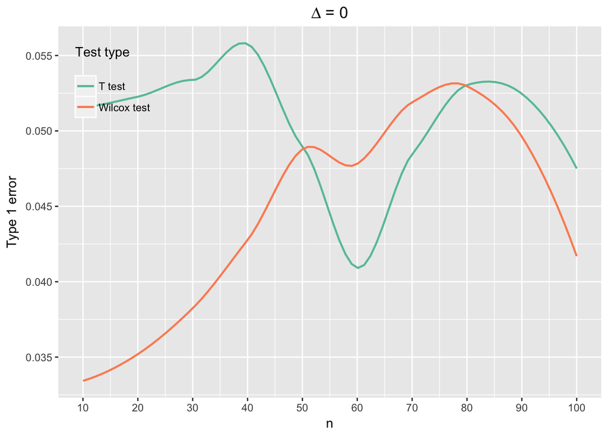

```r
plot9 <- ggplot(data9, aes(n)) + scale_x_continuous(breaks = seq(10, 100, 10), limits = c(10, 100)) +
  geom_smooth(aes(y = T, colour = "T test"), se = FALSE, size = 0.8) +
  geom_smooth(aes(y = W_asy, colour = "Wilcox test"), se = FALSE, size = 0.8) +
  labs(title = expression(paste(Delta," = 0.9")),
       x = "n", y = "Power", color = "Test type\n") +
  theme(plot.title = element_text(hjust = 0.5), legend.position = c(0.8, 0.2), legend.background = element_rect(fill = "transparent")) + scale_colour_brewer(palette = "Set2")
plot0
```

Above is the power plot when $\Delta=0$, which is equivalent to Type I error rate.

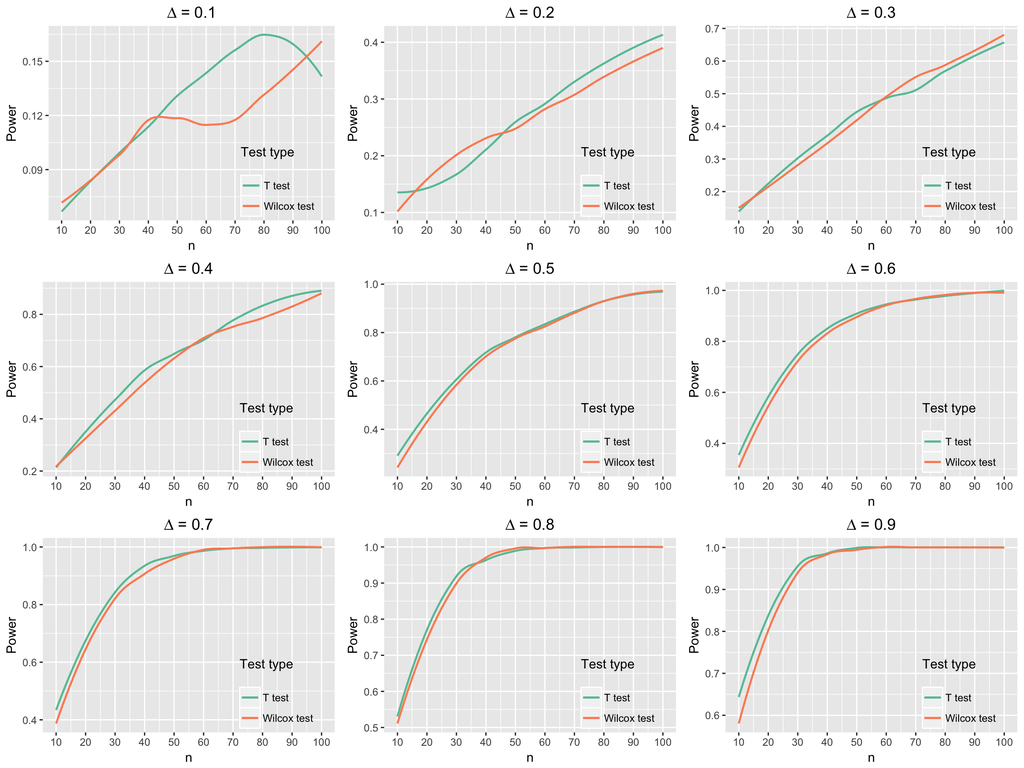

```r
multiplot(plot1,plot4,plot7, plot2, plot5, plot8, plot3, plot6, plot9, cols = 3)
```

From the plot, we know that the power approaches to 1 **faster** when $\Delta$ gets larger. Then we create the power curves for different sample sizes from 20 to 100, with `step = 20`.

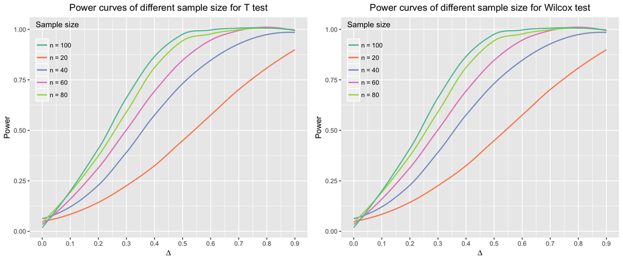

```r
mydata1 = data.frame("delta" = deltavals, "power2" = powermatrix1[2, ], "power4" = powermatrix1[4, ], "power6" = powermatrix1[6, ], "power8" = powermatrix1[8, ], "power10" = powermatrix1[10, ])

mydata2 = data.frame("delta" = deltavals, "power2" = powermatrix2[2, ], "power4" = powermatrix2[4, ],"power6" = powermatrix2[6, ],"power8" = powermatrix2[8, ], "power10" = powermatrix2[10, ])

p1 <- ggplot(mydata1, aes(delta)) + scale_x_continuous(breaks=seq(0, 0.9, 0.1), limits=c(0, 0.9)) +
  geom_smooth(aes(y = power2, colour = "n = 20"), se = FALSE, size = 0.8) +
  geom_smooth(aes(y = power4, colour = "n = 40"), se = FALSE, size = 0.8) +
  geom_smooth(aes(y = power6, colour = "n = 60"), se = FALSE, size = 0.8) +
  geom_smooth(aes(y = power8, colour = "n = 80"), se = FALSE, size = 0.8) +
  geom_smooth(aes(y = power10, colour = "n = 100"), se = FALSE, size = 0.8) +
  labs(title = "Power curves of different sample size for T test",
       x = expression(paste(Delta)), y = "Power", color = "Sample size\n") +
  theme(plot.title = element_text(hjust = 0.5), legend.position = c(0.1,0.8), legend.background = element_rect(fill = "transparent")) + scale_colour_brewer(palette = "Set2")

p2 <- ggplot(mydata1, aes(delta)) + scale_x_continuous(breaks=seq(0, 0.9, 0.1), limits=c(0, 0.9)) +
  geom_smooth(aes(y = power2, colour = "n = 20"), se = FALSE, size = 0.8) +
  geom_smooth(aes(y = power4, colour = "n = 40"), se = FALSE, size = 0.8) +
  geom_smooth(aes(y = power6, colour = "n = 60"), se = FALSE, size = 0.8) +
  geom_smooth(aes(y = power8, colour = "n = 80"), se = FALSE, size = 0.8) +
  geom_smooth(aes(y = power10, colour = "n = 100"), se = FALSE, size = 0.8) +
  labs(title = "Power curves of different sample size for Wilcox test",
       x = expression(paste(Delta)), y = "Power", color = "Sample size\n") +
  theme(plot.title = element_text(hjust = 0.5), legend.position = c(0.1,0.8), legend.background = element_rect(fill = "transparent")) + scale_colour_brewer(palette = "Set2")

multiplot(p1, p2, cols = 2)
```

For a fixed sample size (one line in the graph), the larger $\Delta$ is, the greater power it has.

## (b) Exponential Distribution

Here we let $f_X(x)=e^{-x}$ for $x>0$, and $f_Y(y)=\lambda e^{-\lambda y}$ for $y>0$ and $\lambda \ge1$. The null hypothesis is
$$\lambda = 1.$$
And the alternative hypothesis is
$$H_a: \lambda>1$$
which is equivalent to
$$H_a: \mu_X>\mu_Y$$
**Type 1 Error Rate & Power Analysis**

The simulation parameters are:

- Significance level $\alpha = 0.05$
- Difference $\lambda$ ranges from 1 to 1.9 by 0.1 (when $\lambda = 1$, Type I error rate)
- Sample size $n$ ranges from 10 to 100 by 10
- Replicates $m=500$
- Two tests: T-test & Wilxon test (asymptotic)

Since we stick to $m=500$ replicates as before, the bound for standard error is still 0.0224. We will not calculate se matrix again, the conclusions will be the same.

```r
alpha = 0.05
lambdavals = c(10: 19)/10
nvals = c(10, 20, 30, 40, 50, 60, 70, 80, 90, 100)
m = 500
powermatrix1 <- powermatrix2 <- matrix(0, 10, 10)

function_b <- function(n, lambda, alpha){
  decisions_t <- decisions_asy <- numeric(m)
  for (j in 1:m){
    X = rexp(n)
    Y = rexp(n, rate = lambda)
    # test decision is 1(reject) or 0
    P.value1 = t.test(X, Y, alternative = "greater", var.equal = TRUE)$p.value
    P.value2 = wilcox.test(X, Y, alternative = "greater", exact = FALSE)$p.value
    decisions_t[j] = (P.value1 < alpha)
    decisions_asy[j] = (P.value2 < alpha)
  }
  c(mean(decisions_t), mean(decisions_asy))
}

set.seed(27)
for (i in 1:10){
  n = nvals[i]

  for (j in 1:10){
    lambda = lambdavals[j]
    powermatrix1[i,j] = function_b(n, lambda, alpha)[1]
    powermatrix2[i,j] = function_b(n, lambda, alpha)[2]
  }
}

colnames(powermatrix2) = c("1","1.1","1.2","1.3","1.4","1.5","1.6","1.7","1.8","1.9")
rownames(powermatrix2) = c("n = 10","n = 20","n = 30","n = 40","n = 50",
                          "n = 60","n = 70","n = 80","n = 90","n = 100")
as.data.frame(powermatrix2)
```

```
##             1   1.1   1.2   1.3   1.4   1.5   1.6   1.7   1.8   1.9
## n = 10  0.036 0.076 0.082 0.114 0.108 0.158 0.164 0.266 0.286 0.308
## n = 20  0.052 0.092 0.102 0.188 0.206 0.272 0.340 0.384 0.460 0.534
## n = 30  0.046 0.098 0.142 0.228 0.292 0.396 0.434 0.526 0.566 0.660
## n = 40  0.066 0.084 0.170 0.246 0.348 0.438 0.584 0.662 0.748 0.740
## n = 50  0.062 0.108 0.176 0.286 0.422 0.568 0.642 0.724 0.806 0.866
## n = 60  0.056 0.138 0.194 0.310 0.466 0.596 0.776 0.820 0.858 0.906
## n = 70  0.058 0.118 0.218 0.352 0.520 0.666 0.738 0.832 0.922 0.936
## n = 80  0.046 0.140 0.274 0.422 0.584 0.730 0.826 0.856 0.926 0.962
## n = 90  0.064 0.160 0.282 0.464 0.620 0.746 0.864 0.938 0.948 0.982
## n = 100 0.042 0.128 0.260 0.482 0.644 0.796 0.888 0.960 0.968 0.990
```

Above is the power matrix for asymptotic Wilxon test. Then we create the power curves for different $\lambda$ from 1 to 1.9, with `step = 0.1`.

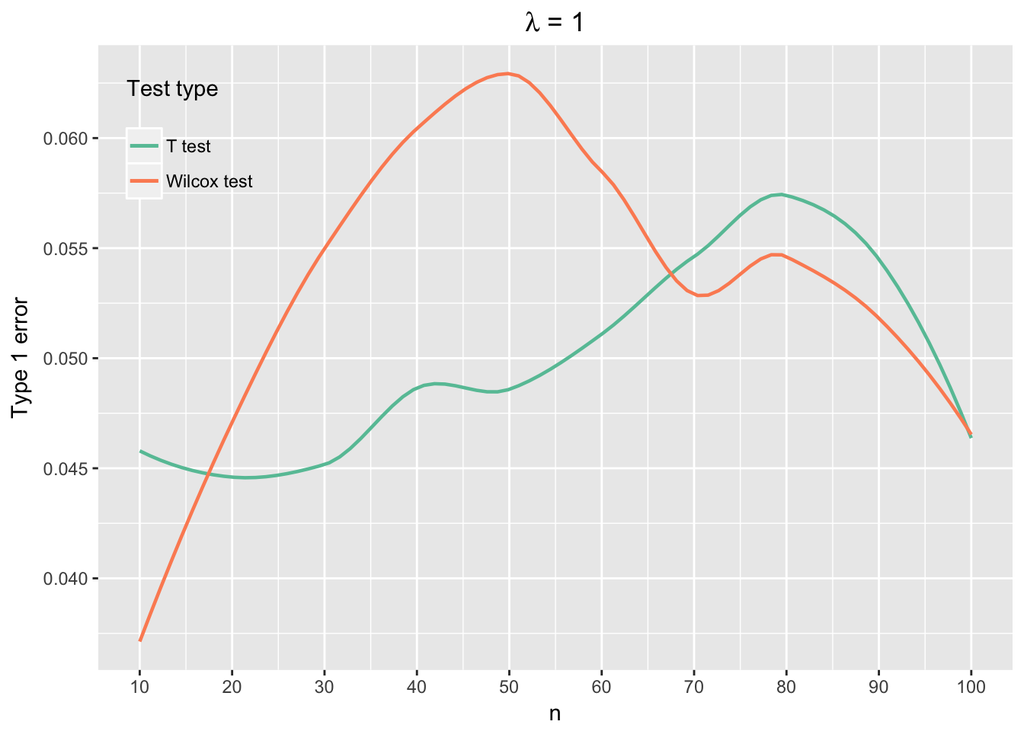

Above is the power plot when $\lambda=1$, which is equivalent to Type I error rate.

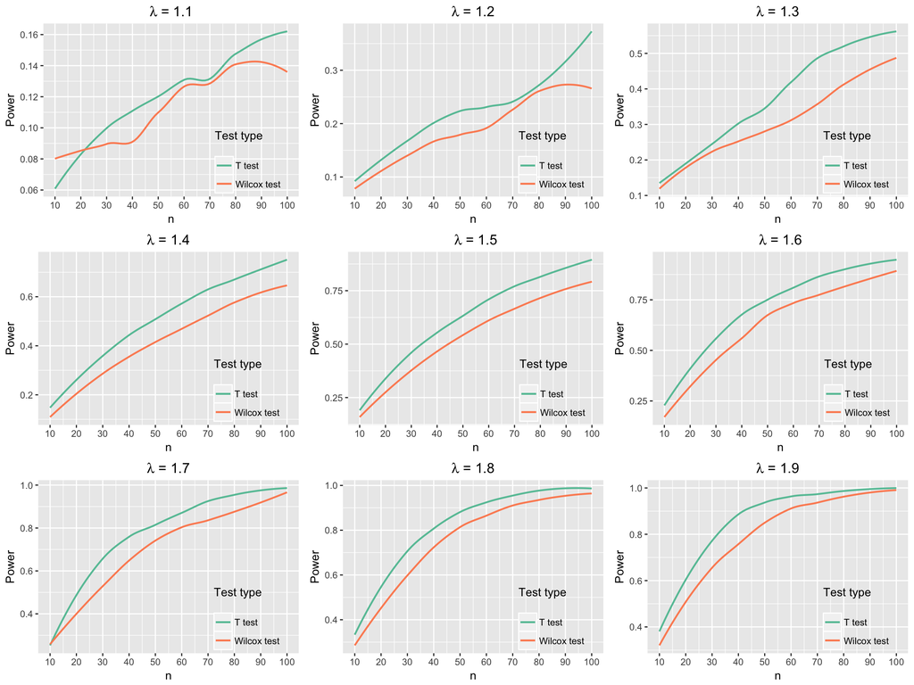

```r
multiplot(plot1,plot4,plot7, plot2, plot5, plot8, plot3, plot6, plot9, cols = 3)
```

From the plot, we know that the power approaches to 1 **faster** when $\lambda$ gets larger. In general, t-test has stronger power than asymptotic Wilcox test. Then we create the power curves for different sample sizes from 20 to 100, with `step = 20`.

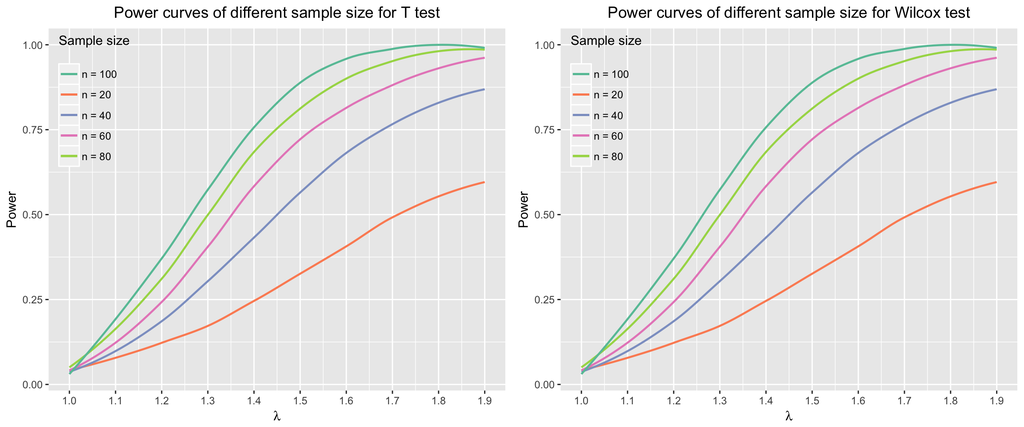

We notice when sample size is fixed, power increases as $\lambda$ gets larger.

## (c) Chi-square Distribution

Let $X\sim \chi^2(1)$ and $Y\sim \chi^2(\nu)$ for $0<\nu \le 1$, we know that $\mu_X=1,\mu_Y=\nu$. So we have
$$H_0:\nu=1 \quad H_a:\nu<1,$$
which is equivalent to
$$H_0:\mu_X=\mu_Y \quad H_a:\mu_X>\mu_Y$$

**Type 1 Error Rate & Power Analysis**

The simulation parameters are:

- Significance level $\alpha = 0.05$
- Difference $\nu$ ranges from 0.1 to 1 by 0.1 (when $\nu = 1$, Type I error rate)
- Sample size $n$ ranges from 10 to 100 by 10
- Replicates $m=500$
- Two tests: T-test & Wilxon test (asymptotic)

Since we stick to $m=500$ replicates as before, the bound for standard error is still 0.0224. We will not calculate se matrix again, the conclusions will be the same.

```r
alpha = 0.05
nuvals = c(1:10)/10
m = 500
nvals = c(10, 20, 30, 40, 50, 60, 70, 80, 90, 100)
powermatrix1 <- powermatrix2 <- matrix(0, 10, 10)

function_c <- function(n, nu, alpha){
  decisions_t <- decisions_asy <- numeric(m)
  for (j in 1:m){
    X = rchisq(n, 1)
    Y = rchisq(n, nu)
    # test decision is 1(reject) or 0
    P.value1 = t.test(X, Y, alternative = "greater", var.equal = TRUE)$p.value
    P.value2 = wilcox.test(X, Y, alternative = "greater", exact = FALSE)$p.value
    decisions_t[j] = (P.value1 < alpha)
    decisions_asy[j] = (P.value2 < alpha)
  }
  c(mean(decisions_t), mean(decisions_asy))
}

set.seed(27)
for (i in 1:10){
  n = nvals[i]

  for (j in 1:10){
    nu = nuvals[j]
    powermatrix1[i,j] = function_c(n, nu, alpha)[1]
    powermatrix2[i,j] = function_c(n, nu, alpha)[2]
  }
}

colnames(powermatrix2) = c("0.1","0.2","0.3","0.4","0.5","0.6","0.7","0.8","0.9","1")
rownames(powermatrix2) = c("n = 10","n = 20","n = 30","n = 40","n = 50",
                          "n = 60","n = 70","n = 80","n = 90","n = 100")
as.data.frame(powermatrix2)
```

```
##           0.1   0.2   0.3   0.4   0.5   0.6   0.7   0.8   0.9     1
## n = 10  0.998 0.884 0.750 0.528 0.408 0.256 0.154 0.102 0.060 0.036
## n = 20  1.000 0.992 0.948 0.836 0.646 0.462 0.286 0.176 0.102 0.046
## n = 30  1.000 1.000 0.998 0.944 0.782 0.570 0.382 0.244 0.098 0.058
## n = 40  1.000 1.000 1.000 0.986 0.914 0.690 0.430 0.240 0.130 0.070
## n = 50  1.000 1.000 1.000 0.992 0.948 0.790 0.542 0.310 0.120 0.052
## n = 60  1.000 1.000 1.000 1.000 0.970 0.868 0.568 0.290 0.132 0.074
## n = 70  1.000 1.000 1.000 0.998 0.986 0.908 0.650 0.378 0.148 0.046
## n = 80  1.000 1.000 1.000 1.000 0.992 0.928 0.734 0.368 0.170 0.046
## n = 90  1.000 1.000 1.000 1.000 0.998 0.956 0.754 0.420 0.168 0.038
## n = 100 1.000 1.000 1.000 1.000 1.000 0.964 0.762 0.422 0.188 0.048
```

Above is the power matrix for asymptotic Wilxon test. Then we create the power curves for different $\nu$ from 0.1 to 1, with `step = 0.1`.

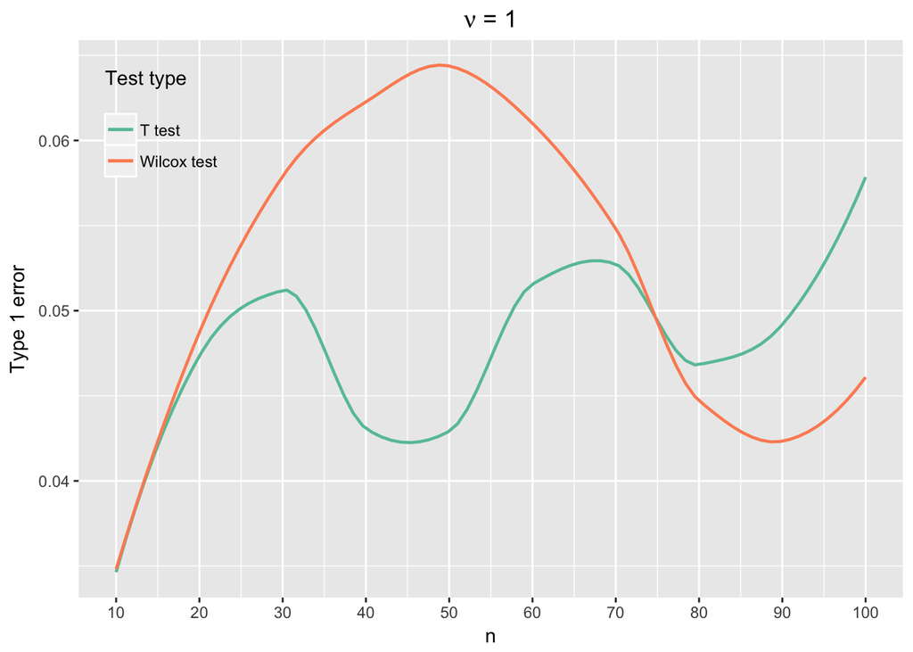

Above is the power plot when $\nu=1$, which is equivalent to Type I error rate.

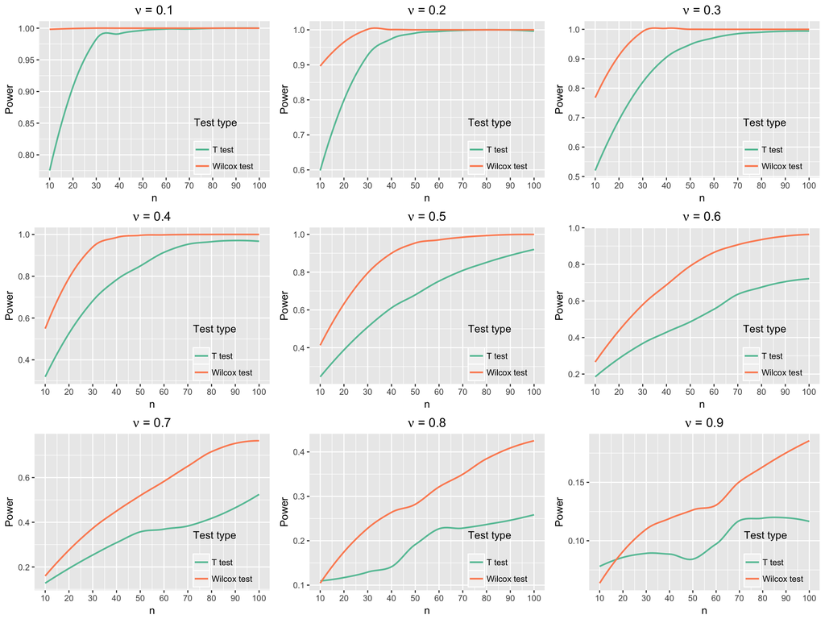

```r
multiplot(plot0,plot3,plot6, plot1, plot4, plot7, plot2, plot5, plot8, cols = 3)
```

From the plot, we know that the power approaches to 1 **faster** when $\nu$ gets closer to 0. In general, asymptotic Wilcox test has stronger power than t test.

Then we create the power curves for different sample sizes from 20 to 100, with `step = 20`.

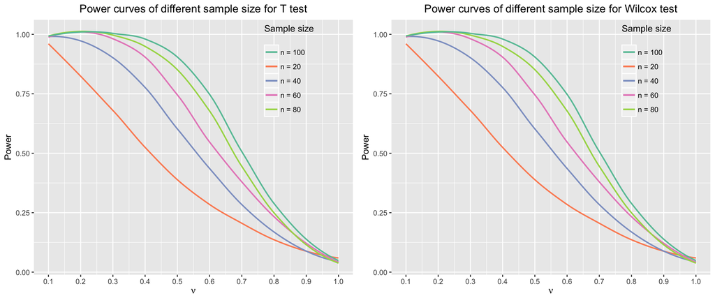

```r
mydata1 = data.frame("nu" = nuvals, "power2" = powermatrix1[2, ],  "power4" = powermatrix1[4, ],
                     "power6" = powermatrix1[6, ],  "power8" = powermatrix1[8, ], "power10" = powermatrix1[10, ])

mydata2 = data.frame("nu" = nuvals, "power2" = powermatrix2[2, ],  "power4" = powermatrix2[4, ],
                     "power6" = powermatrix2[6, ],  "power8" = powermatrix2[8, ], "power10" = powermatrix2[10, ])

p1 <- ggplot(mydata1, aes(nu)) + scale_x_continuous(breaks=seq(0.1, 1, 0.1), limits=c(0.1, 1)) +
  geom_smooth(aes(y = power2, colour = "n = 20"), se = FALSE, size = 0.8) +
  geom_smooth(aes(y = power4, colour = "n = 40"), se = FALSE, size = 0.8) +
  geom_smooth(aes(y = power6, colour = "n = 60"), se = FALSE, size = 0.8) +
  geom_smooth(aes(y = power8, colour = "n = 80"), se = FALSE, size = 0.8) +
  geom_smooth(aes(y = power10, colour = "n = 100"), se = FALSE, size = 0.8) +
  labs(title = "Power curves of different sample size for T test",
       x = expression(paste(nu)), y = "Power", color = "Sample size\n") +
  theme(plot.title = element_text(hjust = 0.5), legend.position = c(0.8,0.8), legend.background = element_rect(fill = "transparent")) + scale_colour_brewer(palette = "Set2")

p2 <- ggplot(mydata1, aes(nu)) + scale_x_continuous(breaks=seq(0.1, 1, 0.1), limits=c(0.1, 1)) +
  geom_smooth(aes(y = power2, colour = "n = 20"), se = FALSE, size = 0.8) +
  geom_smooth(aes(y = power4, colour = "n = 40"), se = FALSE, size = 0.8) +
  geom_smooth(aes(y = power6, colour = "n = 60"), se = FALSE, size = 0.8) +
  geom_smooth(aes(y = power8, colour = "n = 80"), se = FALSE, size = 0.8) +
  geom_smooth(aes(y = power10, colour = "n = 100"), se = FALSE, size = 0.8) +
  labs(title = "Power curves of different sample size for Wilcox test",
       x = expression(paste(nu)), y = "Power", color = "Sample size\n") +
  theme(plot.title = element_text(hjust = 0.5), legend.position = c(0.8, 0.8), legend.background = element_rect(fill = "transparent")) + scale_colour_brewer(palette = "Set2")

multiplot(p1, p2, cols = 2)
```

From the plot, we notice that for a fixed sample size, a test for distribution with parameter $\nu$ closer to 0 will have stronger test power.

# Problem 2 Comparison of Confidence Intervals

## (a) Standard Normal Bootstrap Interval

```r
alpha = 0.1
M = 5000 # number of replicates
nvals = c(20, 50, 100)
CI1 <- CI2 <- CI3 <- CI4 <- U1 <- U2 <- U3 <- U4 <- L1 <- L2 <- L3 <- L4 <- numeric(M)

ML1 <- ML2 <- ML3 <- ML4 <- rep(0, length(nvals))
CP1 <- CP2 <- CP3 <- CP4 <- rep(0, length(nvals))
SE1 <- SE2 <- SE3 <- SE4 <- rep(0, length(nvals))

set.seed(27)
for (k in 1:length(nvals)){
  n = nvals[k]

  for (m in 1:M){
    X1 = rnorm(n, 0, 1)
    X2 = rexp(n, rate = 1)
    X3 = rcauchy(n)
    X4 = runif(n, 0, 1)

    T1 = median(X1)
    T2 = median(X2)
    T3 = median(X3)
    T4 = median(X4)

    B = 100
    Tboot1 <- Tboot2 <- Tboot3 <- Tboot4 <- numeric(B)

    for (b in 1:B){
      xb1 = sample(X1, n, replace = TRUE)
      xb2 = sample(X2, n, replace = TRUE)
      xb3 = sample(X3, n, replace = TRUE)
      xb4 = sample(X4, n, replace = TRUE)
      Tboot1[b] = median(xb1)
      Tboot2[b] = median(xb2)
      Tboot3[b] = median(xb3)
      Tboot4[b] = median(xb4)
    }

  U1[m] = T1 + qnorm(1- alpha/2, 0, 1)*sd(Tboot1)
  L1[m] = T1 - qnorm(1- alpha/2, 0, 1)*sd(Tboot1)
  CI1[m] = ((L1[m] <= qnorm(0.5)) & (U1[m] >= qnorm(0.5)))
  U2[m] = T2 + qnorm(1- alpha/2, 0, 1)*sd(Tboot2)
  L2[m] = T2 - qnorm(1- alpha/2, 0, 1)*sd(Tboot2)
  CI2[m] = ((L2[m] <= qexp(0.5)) & (U2[m] >= qexp(0.5)))
  U3[m] = T3 + qnorm(1- alpha/2, 0, 1)*sd(Tboot3)
  L3[m] = T3 - qnorm(1- alpha/2, 0, 1)*sd(Tboot3)
  CI3[m] = ((L3[m] <= qcauchy(0.5)) & (U3[m] >= qcauchy(0.5)))
  U4[m] = T4 + qnorm(1- alpha/2, 0, 1)*sd(Tboot4)
  L4[m] = T4 - qnorm(1- alpha/2, 0, 1)*sd(Tboot4)
  CI4[m] = ((L4[m] <= qunif(0.5)) & (U4[m] >= qunif(0.5)))
  }

  CP1[k] = round(mean(CI1),3)
  CP2[k] = round(mean(CI2),3)
  CP3[k] = round(mean(CI3),3)
  CP4[k] = round(mean(CI4),3)
  ML1[k] = round(mean(U1 - L1),3)
  ML2[k] = round(mean(U2 - L2),3)
  ML3[k] = round(mean(U3 - L3),3)
  ML4[k] = round(mean(U4 - L4),3)

  options(scipen=999)
  SE1[k] = round(sqrt(CP1[k]*(1-CP1[k])/M),6)
  SE2[k] = round(sqrt(CP2[k]*(1-CP2[k])/M),6)
  SE3[k] = round(sqrt(CP3[k]*(1-CP3[k])/M),6)
  SE4[k] = round(sqrt(CP4[k]*(1-CP4[k])/M),6)
}
```

We summerize the result into the following two tables.

Coverage probabilities

| Distribution | `n = 20` | `n = 50` | `n = 100` |
| --- | --- | --- | --- |
| `N(0,1)` | 0.881 | 0.879 | 0.889 |
| `Exponential(1)` | 0.877 | 0.878 | 0.886 |
| `Cauchy` | 0.927 | 0.912 | 0.9 |
| `Uniform(0,1)` | 0.852 | 0.867 | 0.876 |

Mean lengths of intervals

| Distribution | `n = 20` | `n = 50` | `n = 100` |
| --- | --- | --- | --- |
| `N(0,1)` | 0.919 | 0.588 | 0.416 |
| `Exponential(1)` | 0.758 | 0.474 | 0.334 |
| `Cauchy` | 1.442 | 0.794 | 0.543 |
| `Uniform(0,1)` | 0.34 | 0.228 | 0.164 |

Then we want to show that the `standard error` for the coverage probability estimates is under 0.005 with the following table.

Standard error for the coverage probabability estimates

| Distribution | `n = 20` | `n = 50` | `n = 100` |
| --- | --- | --- | --- |
| `N(0,1)` | 0.004579 | 0.004612 | 0.004442 |
| `Exponential(1)` | 0.004645 | 0.004629 | 0.004495 |
| `Cauchy` | 0.003679 | 0.004006 | 0.004243 |
| `Uniform(0,1)` | 0.005022 | 0.004802 | 0.004661 |

From the table above, we know that all the standard errors for coverage probability estimates are under or very close to 0.005, due to randomness.

## (b) Percentile Bootstrap Confidence Intervals

```r
M = 5000 # number of replicates
nvals = c(20, 50, 100)
CI1 <- CI2 <- CI3 <- CI4 <- U1 <- U2 <- U3 <- U4 <- L1 <- L2 <- L3 <- L4 <- numeric(M)

ML1 <- ML2 <- ML3 <- ML4 <- rep(0, length(nvals))
CP1 <- CP2 <- CP3 <- CP4 <- rep(0, length(nvals))
SE1 <- SE2 <- SE3 <- SE4 <- rep(0, length(nvals))

set.seed(27)
for (k in 1:length(nvals)){
  n = nvals[k]

  for (m in 1:M){
    X1 = rnorm(n, 0, 1)
    X2 = rexp(n, rate = 1)
    X3 = rcauchy(n)
    X4 = runif(n, 0, 1)

    T1 = median(X1)
    T2 = median(X2)
    T3 = median(X3)
    T4 = median(X4)

    B = 100
    Tboot1 <- Tboot2 <- Tboot3 <- Tboot4 <- numeric(B)

    for (b in 1:B){
      xb1 = sample(X1, n, replace = TRUE)
      xb2 = sample(X2, n, replace = TRUE)
      xb3 = sample(X3, n, replace = TRUE)
      xb4 = sample(X4, n, replace = TRUE)
      Tboot1[b] = median(xb1)
      Tboot2[b] = median(xb2)
      Tboot3[b] = median(xb3)
      Tboot4[b] = median(xb4)
    }
    L1[m] = sort(Tboot1)[5]
    U1[m] = sort(Tboot1)[95]
    L2[m] = sort(Tboot2)[5]
    U2[m] = sort(Tboot2)[95]
    L3[m] = sort(Tboot3)[5]
    U3[m] = sort(Tboot3)[95]
    L4[m] = sort(Tboot4)[5]
    U4[m] = sort(Tboot4)[95]

    CI1[m] = ((L1[m] <= qnorm(0.5)) & (U1[m] >= qnorm(0.5)))
    CI2[m] = ((L2[m] <= qexp(0.5)) & (U2[m] >= qexp(0.5)))
    CI3[m] = ((L3[m] <= qcauchy(0.5)) & (U3[m] >= qcauchy(0.5)))
    CI4[m] = ((L4[m] <= qunif(0.5)) & (U4[m] >= qunif(0.5)))
  }

  CP1[k] = round(mean(CI1),3)
  CP2[k] = round(mean(CI2),3)
  CP3[k] = round(mean(CI3),3)
  CP4[k] = round(mean(CI4),3)
  ML1[k] = round(mean(U1 - L1),3)
  ML2[k] = round(mean(U2 - L2),3)
  ML3[k] = round(mean(U3 - L3),3)
  ML4[k] = round(mean(U4 - L4),3)

  options(scipen=999)
  SE1[k] = round(sqrt(CP1[k]*(1-CP1[k])/M),6)
  SE2[k] = round(sqrt(CP2[k]*(1-CP2[k])/M),6)
  SE3[k] = round(sqrt(CP3[k]*(1-CP3[k])/M),6)
  SE4[k] = round(sqrt(CP4[k]*(1-CP4[k])/M),6)
}
```

We summerize the result into the following two tables.

Coverage probabilities

| Distribution | `n = 20` | `n = 50` | `n = 100` |
| --- | --- | --- | --- |
| `N(0,1)` | 0.881 | 0.888 | 0.893 |
| `Exponential(1)` | 0.881 | 0.883 | 0.881 |
| `Cauchy` | 0.885 | 0.898 | 0.891 |
| `Uniform(0,1)` | 0.879 | 0.877 | 0.881 |

Mean lengths of intervals

| Distribution | `n = 20` | `n = 50` | `n = 100` |
| --- | --- | --- | --- |
| `N(0,1)` | 0.887 | 0.572 | 0.406 |
| `Exponential(1)` | 0.713 | 0.456 | 0.324 |
| `Cauchy` | 1.347 | 0.772 | 0.532 |
| `Uniform(0,1)` | 0.327 | 0.221 | 0.16 |

Then we want to show that the `standard error` for the coverage probability estimates is under 0.005 with the following table.

Standard error for the coverage probabability estimates

| Distribution | `n = 20` | `n = 50` | `n = 100` |
| --- | --- | --- | --- |
| `N(0,1)` | 0.004579 | 0.00446 | 0.004372 |
| `Exponential(1)` | 0.004579 | 0.004546 | 0.004579 |
| `Cauchy` | 0.004512 | 0.00428 | 0.004407 |
| `Uniform(0,1)` | 0.004612 | 0.004645 | 0.004579 |

From the table above, we know that all the standard errors for coverage probability estimates are under or very close to 0.005, due to randomness.

## (c) Conclusion

I don’t see a significant difference in terms of coverage probabilities and mean lengths of intervals between two methods. If there is, it seems that the second method (percentile bootstrap) performs slightly better.